# Dərs 3: Bərabərləşdirmə Dizaynları və Məlumat Toplusu Strategiyaları

Təhsildə Test Nəticələrinin Bərabərləşdirilməsi - R Proqram Dili ilə

Test Bərabərləşdirmə Kursu

2025-07-15

# 1 Bərabərləşdirmə Dizaynları və Məlumat Toplusu Strategiyaları

## 1.1 Dərsin Məqsədləri

Bu dərsin sonunda siz:

✅ Müxtəlif bərabərləşdirmə dizaynlarını anlayacaqsınız  
✅ Təsadüfi qruplar dizaynını həyata keçirəcəksiniz  
✅ Ümumi maddə dizaynı metodlarını öyrənəcəksiniz  
✅ Ümumi şəxs dizaynını tətbiq edəcəksiniz  
✅ Optimal dizayn seçimi qərarları verəcəksiniz

## 1.2 Bərabərləşdirmə Dizaynlarına Ümumi Baxış

### 1.2.1 Bərabərləşdirmə Dizaynı Nədir?

**Bərabərləşdirmə dizaynı** müxtəlif test formalarından məlumat toplama strategiyasıdır. Dizayn seçimi bərabərləşdirmənin keyfiyyətini və dəqiqliyini birbaşa təsir edir.

**Əsas prinsipi:**

```
Keyfiyyətli bərabərləşdirmə = Uyğun dizayn + Kifayət məlumat + Düzgün analiz
```

### 1.2.2 Əsas Dizayn Növləri

Esas Beraberleshdirme Dizaynlarinin Muqayisesi

| Dizayn_Novi | Ingilisce_Adi | Esas_Prinsip | Praktik_Tetbiq | Komplekslik |
| --- | --- | --- | --- | --- |
| Tesadufi Qruplar | Random Groups | Muxtlif qruplar → muxtlif testler | Boyuk imtahanlar ⭐⭐⭐ | Sade ⭐⭐⭐ |
| Umumi Madde | Common Item | Her iki testde umumi maddeler | Test inkisafi ⭐⭐⭐ | Orta ⭐⭐ |
| Umumi Sexs | Common Person | Eyni sexsler → her iki test | Pilot testler ⭐⭐ | Cetin ⭐ |
| Counterbalanced | Counterbalanced | Tarazlasdirilmis test teqdimi | Arashdirma meqsedli ⭐ | Cetin ⭐ |

## 1.3 R Mühitinin Hazırlanması

### 1.3.1 Paketlərin Yüklənməsi

```r
# Paketleri aktivlesdirin
suppressMessages({
  library(equate)      # Test beraberleshdirme metodlari
  library(psych)       # Psixometrik analizler
  library(ggplot2)     # Qrafik vizuallashdirma
  library(dplyr)       # Melumat manipulyasiyasi
  library(knitr)       # Cedvel formatlasdirmasi
  library(gridExtra)   # Qrafik teskili
  library(ltm)         # IRT modelleri
  library(mirt)        # Modern IRT
  library(mvtnorm)     # Multivariate normal
})

# Qrafik temasi
theme_set(theme_minimal(base_size = 12))
colors_custom <- c("#3498db", "#e74c3c", "#2ecc71", "#f39c12", "#9b59b6", "#34495e")

cat("✅ R muhiti ugurla konfiqurasiya edildi!\n")
```

```
## ✅ R muhiti ugurla konfiqurasiya edildi!
```

### 1.3.2 Yardımçı Funksiyalar

```r
# Suretli statistika funksiyasi
quick_stats <- function(scores, name = "Test") {
  list(
    name = name,
    n = length(scores),
    mean = round(mean(scores, na.rm = TRUE), 2),
    sd = round(sd(scores, na.rm = TRUE), 2),
    min = min(scores, na.rm = TRUE),
    max = max(scores, na.rm = TRUE),
    skewness = round(psych::skew(scores, na.rm = TRUE), 3),
    kurtosis = round(psych::kurtosi(scores, na.rm = TRUE), 3),
    q25 = round(quantile(scores, 0.25, na.rm = TRUE), 2),
    q50 = round(quantile(scores, 0.50, na.rm = TRUE), 2),
    q75 = round(quantile(scores, 0.75, na.rm = TRUE), 2)
  )
}

# Linear beraberleshdirme funksiyasi
linear_equating <- function(x_scores, y_scores) {
  mean_x <- mean(x_scores, na.rm = TRUE)
  mean_y <- mean(y_scores, na.rm = TRUE)
  sd_x <- sd(x_scores, na.rm = TRUE)
  sd_y <- sd(y_scores, na.rm = TRUE)

  slope <- sd_y / sd_x
  intercept <- mean_y - slope * mean_x

  return(list(
    slope = slope,
    intercept = intercept,
    method = "Linear",
    mean_x = mean_x,
    mean_y = mean_y,
    sd_x = sd_x,
    sd_y = sd_y
  ))
}

# Beraberleshdirme keyfiyyeti qiymetlendirme
evaluate_equating <- function(original, transformed, target, method_name) {
  valid_indices <- !is.na(original) & !is.na(transformed) & !is.na(target)

  if (sum(valid_indices) == 0) {
    return(list(
      method = method_name,
      rmse = NA,
      mae = NA,
      bias = NA,
      correlation = NA,
      valid_n = 0
    ))
  }

  trans_valid <- transformed[valid_indices]
  target_valid <- target[valid_indices]

  rmse <- sqrt(mean((trans_valid - target_valid)^2, na.rm = TRUE))
  mae <- mean(abs(trans_valid - target_valid), na.rm = TRUE)
  bias <- mean(trans_valid - target_valid, na.rm = TRUE)
  correlation <- cor(trans_valid, target_valid, use = "complete.obs")

  return(list(
    method = method_name,
    rmse = round(rmse, 3),
    mae = round(mae, 3),
    bias = round(bias, 3),
    correlation = round(correlation, 3),
    valid_n = sum(valid_indices)
  ))
}

# Test melumati simulyasiya funksiyasi
simulate_test_data <- function(n, mean_score, sd_score, skew_factor = 0) {
  if (skew_factor == 0) {
    scores <- rnorm(n, mean = mean_score, sd = sd_score)
  } else {
    # Beta paylanmasi ile carpiqiq yaratmaq
    if (skew_factor > 0) {
      # Sol carpiq (asan test)
      scores <- rbeta(n, 2, 5) * 100
      scores <- scores * (sd_score / sd(scores)) + (mean_score - mean(scores))
    } else {
      # Sag carpiq (cetin test)
      scores <- rbeta(n, 5, 2) * 100
      scores <- scores * (sd_score / sd(scores)) + (mean_score - mean(scores))
    }
  }

  # Bal araligini mehdudlasdir
  scores <- pmax(0, pmin(100, scores))
  return(scores)
}

cat("✅ Yardimci funksiyalar hazirlandi!\n")
```

```
## ✅ Yardimci funksiyalar hazirlandi!
```

# 2 Təsadüfi Qruplar Dizaynı

## 2.1 Təsadüfi Qruplar Dizaynının Əsasları

Təsadüfi qruplar dizaynında iştirakçılar təsadüfi olaraq müxtəlif qruplara bölünür və hər qrup fərqli test forması alır. Bu ən sadə və geniş istifadə olunan dizayndır.

### 2.1.1 Dizaynın Üstünlükləri və Məhdudiyyətləri

Tesadufi Qruplar Dizayninin Ustunluk ve Mehdudiyyetleri

| Aspekt | Ustunluk | Mehdudiyyet |
| --- | --- | --- |
| Sadelik | ⭐⭐⭐ Cox sade | ❌ Qrup beraberlyi ferzi |
| Heyata kecirme | ⭐⭐⭐ Asan | ❌ Boyuk numune lazim |
| Numune telebi | ⭐⭐ Orta | ❌ Her qrup ucun ayrıca |
| Statistik guc | ⭐⭐ Yaxsi | ❌ Qrup ferqleri |
| Praktiklik | ⭐⭐⭐ Yuksek | ✅ Minimal |
| Bias riski | ⭐⭐⭐ Asagi | ❌ Qrup secimi |
| Test tehlukesizliyi | ⭐⭐⭐ Yuksek | ✅ Minimal |

### 2.1.2 Nümunə Məlumatların Yaradılması

```r
# Tesadufi qruplar dizayni ucun melumat yaratmaq
set.seed(123)
total_participants <- 2000

# Istirakci xususiyyetleri (qabiliyyet, yas, tehsil seviyyesi)
participants <- data.frame(
  participant_id = 1:total_participants,
  ability = rnorm(total_participants, mean = 0, sd = 1),
  age = sample(18:65, total_participants, replace = TRUE),
  education = sample(c("Orta", "Bakalavr", "Magistr"), total_participants,
                    replace = TRUE, prob = c(0.4, 0.4, 0.2)),
  prior_experience = rbinom(total_participants, 1, 0.3)
)

# Tesadufi qrup teyin etme (50-50 bolgu)
participants$group <- sample(c("Form_A", "Form_B"), total_participants,
                            replace = TRUE, prob = c(0.5, 0.5))

# Qrup balansini yoxlayin
group_balance <- table(participants$group)
cat("=== Qrup Balansi ===\n")
```

```
## === Qrup Balansi ===
```

```r
print(group_balance)
```

```
##
## Form_A Form_B
##   1004    996
```

```r
# Qruplarin xususiyyetlerini muqayise edin
group_comparison <- participants %>%
  group_by(group) %>%
  summarise(
    n = n(),
    mean_ability = round(mean(ability), 3),
    sd_ability = round(sd(ability), 3),
    mean_age = round(mean(age), 1),
    prop_high_ed = round(mean(education %in% c("Bakalavr", "Magistr")), 3),
    prop_experience = round(mean(prior_experience), 3),
    .groups = 'drop'
  )

cat("\n=== Qruplarin Xususiyyetleri ===\n")
```

```
##
## === Qruplarin Xususiyyetleri ===
```

```r
kable(group_comparison,
      caption = "Form A ve Form B Qruplarinin Tesviri Statistikalari",
      align = "c")
```

Form A ve Form B Qruplarinin Tesviri Statistikalari

| group | n | mean_ability | sd_ability | mean_age | prop_high_ed | prop_experience |
| --- | --- | --- | --- | --- | --- | --- |
| Form_A | 1004 | 0.051 | 1.008 | 41.3 | 0.58 | 0.283 |
| Form_B | 996 | 0.007 | 0.993 | 41.4 | 0.61 | 0.297 |

```r
# Qrup beraberliyini statistik testle yoxlayin
t_test_ability <- t.test(ability ~ group, data = participants)
chisq_test_education <- chisq.test(table(participants$group, participants$education))

cat("\n=== Qrup Beraberliyi Testleri ===\n")
```

```
##
## === Qrup Beraberliyi Testleri ===
```

```r
cat("Qabiliyyet ferqi (t-test):\n")
```

```
## Qabiliyyet ferqi (t-test):
```

```r
cat("  t =", round(t_test_ability$statistic, 3),
    ", p =", round(t_test_ability$p.value, 3), "\n")
```

```
##   t = 0.993 , p = 0.321
```

```r
cat("Tehsil paylanmasi (χ² test):\n")
```

```
## Tehsil paylanmasi (χ² test):
```

```r
cat("  χ² =", round(chisq_test_education$statistic, 3),
    ", p =", round(chisq_test_education$p.value, 3), "\n")
```

```
##   χ² = 1.966 , p = 0.374
```

```r
if (t_test_ability$p.value > 0.05 & chisq_test_education$p.value > 0.05) {
  cat("✅ Qruplar statistik olaraq beraberdir\n")
} else {
  cat("⚠️ Qruplar arasinda ehemiyyetli ferq var\n")
}
```

```
## ✅ Qruplar statistik olaraq beraberdir
```

### 2.1.3 Test Formalarının Yaradılması

```r
# Test ballari ucun bos sutun yaradin
participants$test_score <- NA

# Form A ve Form B test ballarini yaradin
# Form A: Bir qeder asan (yuksek ortalama)
form_a_indices <- which(participants$group == "Form_A")
participants$test_score[form_a_indices] <- round(
  75 + 15 * participants$ability[form_a_indices] + rnorm(length(form_a_indices), 0, 5), 0
)

# Form B: Bir qeder cetin (asagi ortalama)
form_b_indices <- which(participants$group == "Form_B")
participants$test_score[form_b_indices] <- round(
  70 + 15 * participants$ability[form_b_indices] + rnorm(length(form_b_indices), 0, 5), 0
)

# Bal araligini mehdudlasdir
participants$test_score <- pmax(0, pmin(100, participants$test_score))

# Ayrıca melumat frame-leri yaradin
form_a_data <- participants[participants$group == "Form_A", ]
form_b_data <- participants[participants$group == "Form_B", ]

# Test formalarinin statistikalari
form_a_stats <- quick_stats(form_a_data$test_score, "Form A")
form_b_stats <- quick_stats(form_b_data$test_score, "Form B")

test_forms_summary <- data.frame(
  Test_Form = c("Form A", "Form B"),
  N = c(form_a_stats$n, form_b_stats$n),
  Mean = c(form_a_stats$mean, form_b_stats$mean),
  SD = c(form_a_stats$sd, form_b_stats$sd),
  Q25 = c(form_a_stats$q25, form_b_stats$q25),
  Q50 = c(form_a_stats$q50, form_b_stats$q50),
  Q75 = c(form_a_stats$q75, form_b_stats$q75),
  Skewness = c(form_a_stats$skewness, form_b_stats$skewness),
  Kurtosis = c(form_a_stats$kurtosis, form_b_stats$kurtosis)
)

cat("=== Test Formalarinin Tesviri Statistikalari ===\n")
```

```
## === Test Formalarinin Tesviri Statistikalari ===
```

```r
kable(test_forms_summary,
      caption = "Form A ve Form B-nin Bal Paylanmalari",
      align = "c")
```

Form A ve Form B-nin Bal Paylanmalari

| Test_Form | N | Mean | SD | Q25 | Q50 | Q75 | Skewness | Kurtosis |
| --- | --- | --- | --- | --- | --- | --- | --- | --- |
| Form A | 1004 | 75.20 | 15.04 | 65 | 76 | 86 | -0.303 | -0.381 |
| Form B | 996 | 69.73 | 15.19 | 59 | 70 | 81 | -0.146 | -0.381 |

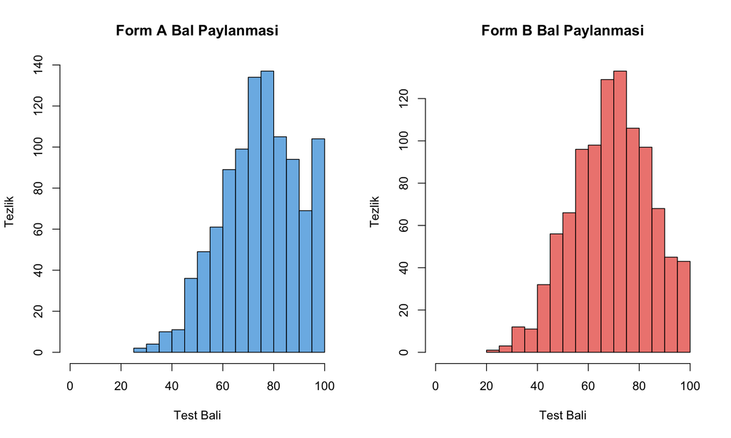

```r
# Paylanmalari vizuallashdirin
par(mfrow = c(1, 2))
hist(form_a_data$test_score, breaks = 25, col = adjustcolor(colors_custom[1], alpha.f = 0.7),
     main = "Form A Bal Paylanmasi", xlab = "Test Bali", ylab = "Tezlik",
     xlim = c(0, 100))

hist(form_b_data$test_score, breaks = 25, col = adjustcolor(colors_custom[2], alpha.f = 0.7),
     main = "Form B Bal Paylanmasi", xlab = "Test Bali", ylab = "Tezlik",
     xlim = c(0, 100))
```

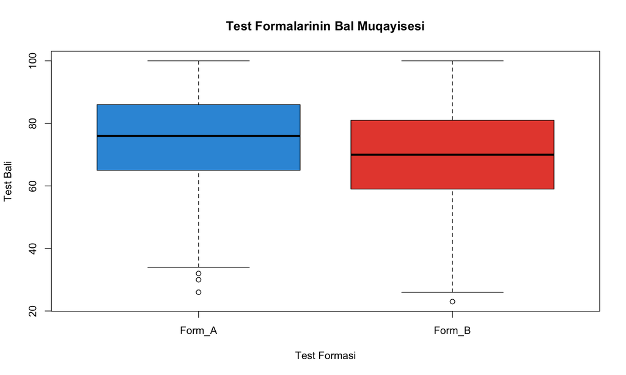

```r
# Box plot muqayisesi
par(mfrow = c(1, 1))
boxplot(test_score ~ group, data = participants,
        col = colors_custom[1:2],
        main = "Test Formalarinin Bal Muqayisesi",
        xlab = "Test Formasi", ylab = "Test Bali")
```

## 2.2 Təsadüfi Qruplar Bərabərləşdirməsi

### 2.2.1 Linear Bərabərləşdirmə Tətbiqi

```r
# Form A-dan Form B-ye linear beraberleshdirme
rg_linear_eq <- linear_equating(form_a_data$test_score, form_b_data$test_score)

cat("=== Tesadufi Qruplar Linear Beraberleshdirme ===\n")
```

```
## === Tesadufi Qruplar Linear Beraberleshdirme ===
```

```r
cat("Slope (emsal):", round(rg_linear_eq$slope, 4), "\n")
```

```
## Slope (emsal): 1.01
```

```r
cat("Intercept (kesisme):", round(rg_linear_eq$intercept, 2), "\n")
```

```
## Intercept (kesisme): -6.22
```

```r
cat("Form A ortalama:", rg_linear_eq$mean_x, "\n")
```

```
## Form A ortalama: 75.19821
```

```r
cat("Form B ortalama:", rg_linear_eq$mean_y, "\n")
```

```
## Form B ortalama: 69.73193
```

```r
cat("Form A SD:", rg_linear_eq$sd_x, "\n")
```

```
## Form A SD: 15.0421
```

```r
cat("Form B SD:", rg_linear_eq$sd_y, "\n")
```

```
## Form B SD: 15.19228
```

```r
# Form A ballarini Form B-ye cevirin
form_a_data$equated_score <- rg_linear_eq$intercept + rg_linear_eq$slope * form_a_data$test_score
form_a_data$equated_score <- pmax(0, pmin(100, form_a_data$equated_score))

# Beraberleshdirme keyfiyyetini qiymetlendirin
# Form A-ni esas kimi goturub, Form B ile muqayise edirik
rg_quality <- evaluate_equating(
  original = form_a_data$test_score,
  transformed = form_a_data$equated_score,
  target = form_b_data$test_score[1:nrow(form_a_data)], # Sample matching for comparison
  method_name = "Random Groups Linear"
)

cat("\n=== Beraberleshdirme Keyfiyyeti ===\n")
```

```
##
## === Beraberleshdirme Keyfiyyeti ===
```

```r
cat("RMSE:", rg_quality$rmse, "\n")
```

```
## RMSE: 21.977
```

```r
cat("MAE:", rg_quality$mae, "\n")
```

```
## MAE: 17.789
```

```r
cat("Bias:", rg_quality$bias, "\n")
```

```
## Bias: -0.024
```

```r
cat("Correlation:", rg_quality$correlation, "\n")
```

```
## Correlation: -0.048
```

```r
# Numune transformasiyalar
sample_scores <- c(40, 50, 60, 70, 80, 90)
sample_transformed <- rg_linear_eq$intercept + rg_linear_eq$slope * sample_scores
sample_transformed <- pmax(0, pmin(100, sample_transformed))

transformation_examples <- data.frame(
  Form_A_Score = sample_scores,
  Form_B_Equivalent = round(sample_transformed, 1),
  Difference = round(sample_transformed - sample_scores, 1)
)

cat("\n=== Numune Transformasiyalar ===\n")
```

```
##
## === Numune Transformasiyalar ===
```

```r
kable(transformation_examples,
      caption = "Form A Ballarinin Form B Ekvivalentleri",
      align = "c")
```

Form A Ballarinin Form B Ekvivalentleri

| Form_A_Score | Form_B_Equivalent | Difference |
| --- | --- | --- |
| 40 | 34.2 | -5.8 |
| 50 | 44.3 | -5.7 |
| 60 | 54.4 | -5.6 |
| 70 | 64.5 | -5.5 |
| 80 | 74.6 | -5.4 |
| 90 | 84.7 | -5.3 |

### 2.2.2 Bərabərləşdirmə Əyrisinin Vizualizasiyası

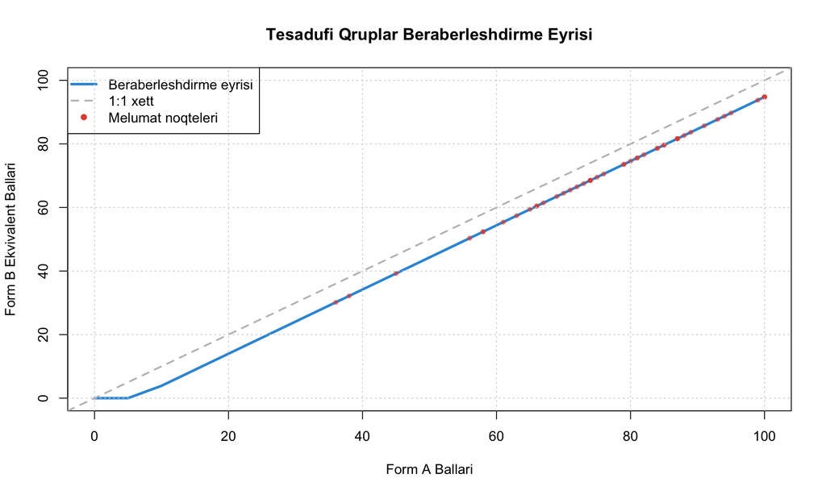

```r
# Beraberleshdirme eyrisini cekmek
score_range <- seq(0, 100, 5)
equated_range <- rg_linear_eq$intercept + rg_linear_eq$slope * score_range
equated_range <- pmax(0, pmin(100, equated_range))

plot(score_range, equated_range, type = "l", col = colors_custom[1], lwd = 3,
     main = "Tesadufi Qruplar Beraberleshdirme Eyrisi",
     xlab = "Form A Ballari", ylab = "Form B Ekvivalent Ballari",
     xlim = c(0, 100), ylim = c(0, 100))

# 1:1 xetti elave edin
abline(0, 1, col = "gray", lty = 2, lwd = 2)

# Melumat noqteleri
points(form_a_data$test_score[1:50], form_a_data$equated_score[1:50],
       col = adjustcolor(colors_custom[2], alpha.f = 0.6), pch = 16, cex = 0.8)

legend("topleft",
       c("Beraberleshdirme eyrisi", "1:1 xett", "Melumat noqteleri"),
       col = c(colors_custom[1], "gray", colors_custom[2]),
       lty = c(1, 2, NA), lwd = c(3, 2, NA), pch = c(NA, NA, 16))

grid()
```

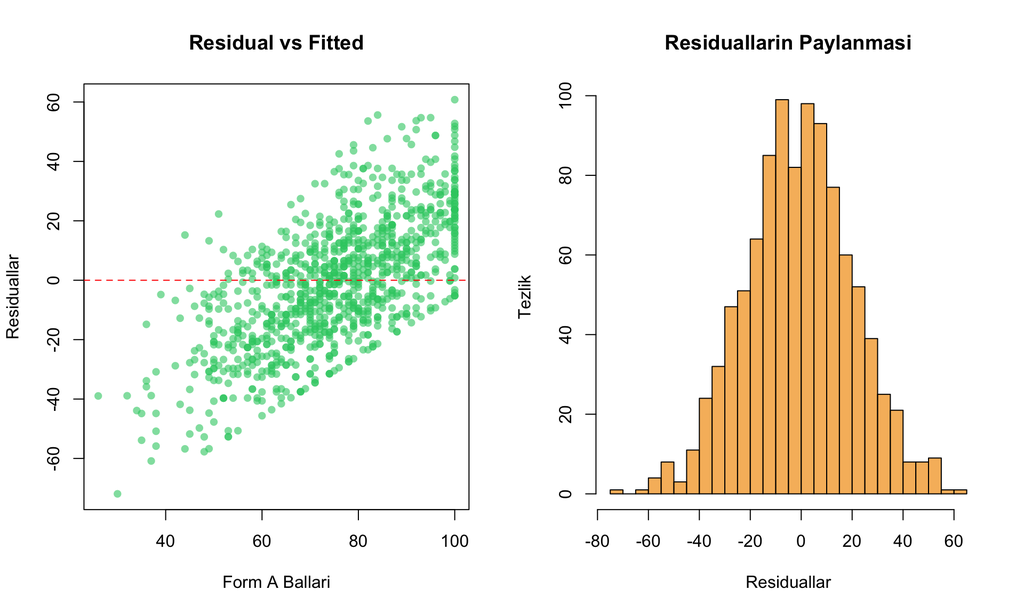

```r
# Residual analizi
residuals_rg <- form_a_data$equated_score -
                sample(form_b_data$test_score, nrow(form_a_data), replace = TRUE)

par(mfrow = c(1, 2))
plot(form_a_data$test_score, residuals_rg,
     col = adjustcolor(colors_custom[3], alpha.f = 0.6), pch = 16,
     main = "Residual vs Fitted", xlab = "Form A Ballari", ylab = "Residuallar")
abline(h = 0, col = "red", lty = 2)

hist(residuals_rg, breaks = 20, col = adjustcolor(colors_custom[4], alpha.f = 0.7),
     main = "Residuallarin Paylanmasi", xlab = "Residuallar", ylab = "Tezlik")
```

# 3 Ümumi Maddə Dizaynı

## 3.1 Ümumi Maddə Dizaynının Əsasları

Ümumi maddə dizaynında iki test forması arasında ümumi maddələr mövcuddur. Bu maddələr əlaqələndirici rolunu oynayır və bərabərləşdirmə üçün əsas təşkil edir.

### 3.1.1 Dizayn Strukturu

Umumi Madde Dizayninin Struktur Numunesi

| Madde_Novi | Form_A | Form_B | Meqsed |
| --- | --- | --- | --- |
| Form A unikal | 25 madde | 0 madde | A formunun xususi mezmunu |
| Umumi maddeler | 15 madde | 15 madde | Beraberleshdirme elaqesi |
| Form B unikal | 0 madde | 25 madde | B formunun xususi mezmunu |
| Cemi | 40 madde | 40 madde | Tam test uzunlugu |

### 3.1.2 Ümumi Maddə Məlumatlarının Simulyasiyası

```r
# Umumi madde dizayni ucun melumat simulyasiyasi
set.seed(456)
n_students_ci <- 1200
n_common_items <- 15
n_unique_a <- 25
n_unique_b <- 25

# Sagird qabiliyyetlerini yaradin (IRT theta parametri)
student_abilities <- rnorm(n_students_ci, mean = 0, sd = 1)

# Madde cetinliklerini ve diskriminasiyalarini yaradin
# Umumi maddeler
common_item_difficulties <- rnorm(n_common_items, mean = 0, sd = 1)
common_item_discriminations <- rlnorm(n_common_items, meanlog = 0, sdlog = 0.3)

# Form A unikal maddeler (bir qeder asan)
unique_a_difficulties <- rnorm(n_unique_a, mean = -0.3, sd = 1)
unique_a_discriminations <- rlnorm(n_unique_a, meanlog = 0, sdlog = 0.3)

# Form B unikal maddeler (bir qeder cetin)
unique_b_difficulties <- rnorm(n_unique_b, mean = 0.3, sd = 1)
unique_b_discriminations <- rlnorm(n_unique_b, meanlog = 0, sdlog = 0.3)

# 2PL IRT modeli ile cavab melumatlarini yaradin
generate_irt_responses <- function(abilities, difficulties, discriminations) {
  n_persons <- length(abilities)
  n_items <- length(difficulties)
  responses <- matrix(NA, n_persons, n_items)

  for (i in 1:n_persons) {
    for (j in 1:n_items) {
      prob <- 1 / (1 + exp(-discriminations[j] * (abilities[i] - difficulties[j])))
      responses[i, j] <- rbinom(1, 1, prob)
    }
  }

  return(responses)
}

# Cavab melumatlarini yaradin
common_responses <- generate_irt_responses(student_abilities,
                                          common_item_difficulties,
                                          common_item_discriminations)

unique_a_responses <- generate_irt_responses(student_abilities,
                                            unique_a_difficulties,
                                            unique_a_discriminations)

unique_b_responses <- generate_irt_responses(student_abilities,
                                            unique_b_difficulties,
                                            unique_b_discriminations)

# Test ballarini hesablayin
form_a_scores <- rowSums(common_responses) + rowSums(unique_a_responses)
form_b_scores <- rowSums(common_responses) + rowSums(unique_b_responses)
common_scores <- rowSums(common_responses)

# Umumi madde melumatlarini data frame-e yerlesdirin
ci_data <- data.frame(
  student_id = 1:n_students_ci,
  ability = student_abilities,
  form_a_score = form_a_scores,
  form_b_score = form_b_scores,
  common_score = common_scores,
  form_a_unique = rowSums(unique_a_responses),
  form_b_unique = rowSums(unique_b_responses)
)

# Esas statistikalari hesablayin
ci_stats_summary <- data.frame(
  Test_Component = c("Form A Total", "Form B Total", "Common Items", "Form A Unique", "Form B Unique"),
  N = rep(n_students_ci, 5),
  Mean = c(mean(ci_data$form_a_score), mean(ci_data$form_b_score),
           mean(ci_data$common_score), mean(ci_data$form_a_unique), mean(ci_data$form_b_unique)),
  SD = c(sd(ci_data$form_a_score), sd(ci_data$form_b_score),
         sd(ci_data$common_score), sd(ci_data$form_a_unique), sd(ci_data$form_b_unique)),
  Min = c(min(ci_data$form_a_score), min(ci_data$form_b_score),
          min(ci_data$common_score), min(ci_data$form_a_unique), min(ci_data$form_b_unique)),
  Max = c(max(ci_data$form_a_score), max(ci_data$form_b_score),
          max(ci_data$common_score), max(ci_data$form_a_unique), max(ci_data$form_b_unique))
)

ci_stats_summary[, 3:6] <- round(ci_stats_summary[, 3:6], 2)

cat("=== Umumi Madde Dizayni Statistikalari ===\n")
```

```
## === Umumi Madde Dizayni Statistikalari ===
```

```r
kable(ci_stats_summary,
      caption = "Umumi Madde Dizayninda Test Komponentlerinin Statistikalari",
      align = "c")
```

Umumi Madde Dizayninda Test Komponentlerinin Statistikalari

| Test_Component | N | Mean | SD | Min | Max |
| --- | --- | --- | --- | --- | --- |
| Form A Total | 1200 | 20.53 | 7.66 | 1 | 39 |
| Form B Total | 1200 | 18.13 | 7.61 | 2 | 37 |
| Common Items | 1200 | 6.68 | 3.14 | 0 | 14 |
| Form A Unique | 1200 | 13.86 | 4.97 | 1 | 25 |
| Form B Unique | 1200 | 11.45 | 4.92 | 0 | 24 |

```r
# Korrelyasiya matrisi
ci_correlations <- cor(ci_data[, c("form_a_score", "form_b_score", "common_score",
                                  "form_a_unique", "form_b_unique")])
ci_correlations <- round(ci_correlations, 3)

cat("\n=== Komponentler Arasi Korrelyasiyalar ===\n")
```

```
##
## === Komponentler Arasi Korrelyasiyalar ===
```

```r
kable(ci_correlations,
      caption = "Test Komponentleri Arasinda Korrelyasiya Matrisi",
      align = "c")
```

Test Komponentleri Arasinda Korrelyasiya Matrisi

|  | form_a_score | form_b_score | common_score | form_a_unique | form_b_unique |
| --- | --- | --- | --- | --- | --- |
| form_a_score | 1.000 | 0.922 | 0.910 | 0.965 | 0.844 |
| form_b_score | 0.922 | 1.000 | 0.911 | 0.844 | 0.965 |
| common_score | 0.910 | 0.911 | 1.000 | 0.771 | 0.771 |
| form_a_unique | 0.965 | 0.844 | 0.771 | 1.000 | 0.813 |
| form_b_unique | 0.844 | 0.965 | 0.771 | 0.813 | 1.000 |

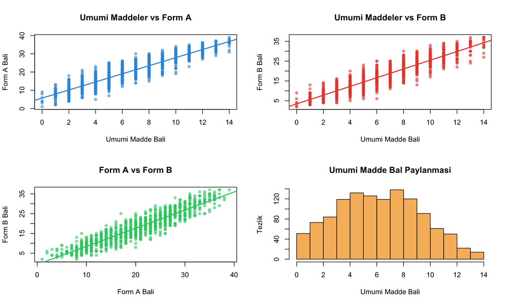

```r
# Vizualizasiya
par(mfrow = c(2, 2))

# Umumi maddeler vs umumi ballar
plot(ci_data$common_score, ci_data$form_a_score,
     col = adjustcolor(colors_custom[1], alpha.f = 0.6), pch = 16,
     main = "Umumi Maddeler vs Form A",
     xlab = "Umumi Madde Bali", ylab = "Form A Bali")
abline(lm(form_a_score ~ common_score, data = ci_data), col = colors_custom[1], lwd = 2)

plot(ci_data$common_score, ci_data$form_b_score,
     col = adjustcolor(colors_custom[2], alpha.f = 0.6), pch = 16,
     main = "Umumi Maddeler vs Form B",
     xlab = "Umumi Madde Bali", ylab = "Form B Bali")
abline(lm(form_b_score ~ common_score, data = ci_data), col = colors_custom[2], lwd = 2)

# Form A vs Form B
plot(ci_data$form_a_score, ci_data$form_b_score,
     col = adjustcolor(colors_custom[3], alpha.f = 0.6), pch = 16,
     main = "Form A vs Form B",
     xlab = "Form A Bali", ylab = "Form B Bali")
abline(lm(form_b_score ~ form_a_score, data = ci_data), col = colors_custom[3], lwd = 2)

# Umumi maddelerin paylanmasi
hist(ci_data$common_score, breaks = 15, col = adjustcolor(colors_custom[4], alpha.f = 0.7),
     main = "Umumi Madde Bal Paylanmasi", xlab = "Umumi Madde Bali", ylab = "Tezlik")
```

## 3.2 Ümumi Maddə Bərabərləşdirmə Metodları

### 3.2.1 Zəncir Bərabərləşdirmə (Chained Equating)

```r
# Zencir beraberleshdirme metodu
# Form A → Umumi Maddeler → Form B

# Addim 1: Form A total-dan umumi maddelere beraberleshdirme
eq_a_to_common <- linear_equating(ci_data$form_a_score, ci_data$common_score)

# Addim 2: Umumi maddelerden Form B total-a beraberleshdirme
eq_common_to_b <- linear_equating(ci_data$common_score, ci_data$form_b_score)

# Addim 3: Zencir kombinasiyasi (composite transformation)
# y = a₂ + b₂(a₁ + b₁x) = (a₂ + b₂a₁) + (b₂b₁)x
chained_intercept <- eq_common_to_b$intercept + eq_common_to_b$slope * eq_a_to_common$intercept
chained_slope <- eq_common_to_b$slope * eq_a_to_common$slope

cat("=== Zencir Beraberleshdirme Parametrleri ===\n")
```

```
## === Zencir Beraberleshdirme Parametrleri ===
```

```r
cat("Addim 1 (Form A → Umumi):\n")
```

```
## Addim 1 (Form A → Umumi):
```

```r
cat("  Slope:", round(eq_a_to_common$slope, 4), "\n")
```

```
##   Slope: 0.4104
```

```r
cat("  Intercept:", round(eq_a_to_common$intercept, 2), "\n")
```

```
##   Intercept: -1.75
```

```r
cat("\nAddim 2 (Umumi → Form B):\n")
```

```
##
## Addim 2 (Umumi → Form B):
```

```r
cat("  Slope:", round(eq_common_to_b$slope, 4), "\n")
```

```
##   Slope: 2.4219
```

```r
cat("  Intercept:", round(eq_common_to_b$intercept, 2), "\n")
```

```
##   Intercept: 1.96
```

```r
cat("\nZencir Neticesi (Form A → Form B):\n")
```

```
##
## Zencir Neticesi (Form A → Form B):
```

```r
cat("  Final Slope:", round(chained_slope, 4), "\n")
```

```
##   Final Slope: 0.9939
```

```r
cat("  Final Intercept:", round(chained_intercept, 2), "\n")
```

```
##   Final Intercept: -2.28
```

```r
# Zencir transformasiyasi tetbiqi
ci_data$form_a_to_b_chained <- chained_intercept + chained_slope * ci_data$form_a_score
ci_data$form_a_to_b_chained <- pmax(0, pmin(40, ci_data$form_a_to_b_chained))

# Keyfiyyet qiymetlendirmesi
chained_quality <- evaluate_equating(
  original = ci_data$form_a_score,
  transformed = ci_data$form_a_to_b_chained,
  target = ci_data$form_b_score,
  method_name = "Chained Common Item"
)

cat("\n=== Zencir Beraberleshdirme Keyfiyyeti ===\n")
```

```
##
## === Zencir Beraberleshdirme Keyfiyyeti ===
```

```r
cat("RMSE:", chained_quality$rmse, "\n")
```

```
## RMSE: 3.009
```

```r
cat("MAE:", chained_quality$mae, "\n")
```

```
## MAE: 2.427
```

```r
cat("Bias:", chained_quality$bias, "\n")
```

```
## Bias: 0.002
```

```r
cat("Correlation:", chained_quality$correlation, "\n")
```

```
## Correlation: 0.922
```

### 3.2.2 Tucker Bərabərləşdirmə Metodu

```r
# Tucker linear equating metodu
# Bu metod umumi maddeleri istifade ederek daha deqiq beraberleshdirme aparir

tucker_equating <- function(x_total, y_total, x_common, y_common) {
  # Korrelyasiyalari hesablayin
  r_xy <- cor(x_total, y_total)
  r_x_common <- cor(x_total, x_common)
  r_y_common <- cor(y_total, y_common)

  # Guvenilirlik emsallarini texmin edin
  rel_x <- r_x_common^2
  rel_y <- r_y_common^2

  # Tucker duzelisleri
  sx <- sd(x_total)
  sy <- sd(y_total)
  mx <- mean(x_total)
  my <- mean(y_total)

  # Tucker slope ve intercept
  slope_tucker <- (sy / sx) * sqrt(rel_y / rel_x)
  intercept_tucker <- my - slope_tucker * mx

  return(list(
    slope = slope_tucker,
    intercept = intercept_tucker,
    reliability_x = rel_x,
    reliability_y = rel_y,
    method = "Tucker"
  ))
}

# Tucker metodunu tetbiq edin
tucker_eq <- tucker_equating(
  x_total = ci_data$form_a_score,
  y_total = ci_data$form_b_score,
  x_common = ci_data$common_score,
  y_common = ci_data$common_score  # Eyni umumi maddeler
)

cat("=== Tucker Beraberleshdirme Parametrleri ===\n")
```

```
## === Tucker Beraberleshdirme Parametrleri ===
```

```r
cat("Tucker Slope:", round(tucker_eq$slope, 4), "\n")
```

```
## Tucker Slope: 0.9946
```

```r
cat("Tucker Intercept:", round(tucker_eq$intercept, 2), "\n")
```

```
## Tucker Intercept: -2.29
```

```r
cat("Form A guvenilirlik texmini:", round(tucker_eq$reliability_x, 3), "\n")
```

```
## Form A guvenilirlik texmini: 0.829
```

```r
cat("Form B guvenilirlik texmini:", round(tucker_eq$reliability_y, 3), "\n")
```

```
## Form B guvenilirlik texmini: 0.83
```

```r
# Tucker transformasiyasi
ci_data$form_a_to_b_tucker <- tucker_eq$intercept + tucker_eq$slope * ci_data$form_a_score
ci_data$form_a_to_b_tucker <- pmax(0, pmin(40, ci_data$form_a_to_b_tucker))

# Tucker keyfiyyeti
tucker_quality <- evaluate_equating(
  original = ci_data$form_a_score,
  transformed = ci_data$form_a_to_b_tucker,
  target = ci_data$form_b_score,
  method_name = "Tucker Common Item"
)

cat("\n=== Tucker Beraberleshdirme Keyfiyyeti ===\n")
```

```
##
## === Tucker Beraberleshdirme Keyfiyyeti ===
```

```r
cat("RMSE:", tucker_quality$rmse, "\n")
```

```
## RMSE: 3.01
```

```r
cat("MAE:", tucker_quality$mae, "\n")
```

```
## MAE: 2.428
```

```r
cat("Bias:", tucker_quality$bias, "\n")
```

```
## Bias: 0.002
```

```r
cat("Correlation:", tucker_quality$correlation, "\n")
```

```
## Correlation: 0.922
```

### 3.2.3 Metodların Müqayisəsi

```r
# Butun metodlari muqayise edin
# Elave olaraq sade linear beraberleshdirme de elave edek
simple_linear_eq <- linear_equating(ci_data$form_a_score, ci_data$form_b_score)
ci_data$form_a_to_b_simple <- simple_linear_eq$intercept + simple_linear_eq$slope * ci_data$form_a_score
ci_data$form_a_to_b_simple <- pmax(0, pmin(40, ci_data$form_a_to_b_simple))

simple_quality <- evaluate_equating(
  original = ci_data$form_a_score,
  transformed = ci_data$form_a_to_b_simple,
  target = ci_data$form_b_score,
  method_name = "Simple Linear"
)

# Muqayise cedveli
method_comparison_ci <- data.frame(
  Method = c("Simple Linear", "Chained Common Item", "Tucker Common Item"),
  RMSE = c(simple_quality$rmse, chained_quality$rmse, tucker_quality$rmse),
  MAE = c(simple_quality$mae, chained_quality$mae, tucker_quality$mae),
  Bias = c(simple_quality$bias, chained_quality$bias, tucker_quality$bias),
  Correlation = c(simple_quality$correlation, chained_quality$correlation, tucker_quality$correlation)
)

cat("=== Umumi Madde Metodlarinin Muqayisesi ===\n")
```

```
## === Umumi Madde Metodlarinin Muqayisesi ===
```

```r
kable(method_comparison_ci,
      caption = "Muxtlif Umumi Madde Beraberleshdirme Metodlarinin Performansi",
      align = c("l", "c", "c", "c", "c"))
```

Muxtlif Umumi Madde Beraberleshdirme Metodlarinin Performansi

| Method | RMSE | MAE | Bias | Correlation |
| --- | --- | --- | --- | --- |
| Simple Linear | 3.009 | 2.427 | 0.002 | 0.922 |
| Chained Common Item | 3.009 | 2.427 | 0.002 | 0.922 |
| Tucker Common Item | 3.010 | 2.428 | 0.002 | 0.922 |

```r
# En yaxsi metodu mueyyen edin
best_rmse_ci <- method_comparison_ci$Method[which.min(method_comparison_ci$RMSE)]
best_correlation_ci <- method_comparison_ci$Method[which.max(method_comparison_ci$Correlation)]

cat("\n=== En Yaxsi Performans ===\n")
```

```
##
## === En Yaxsi Performans ===
```

```r
cat("RMSE uzre en yaxsi:", best_rmse_ci, "\n")
```

```
## RMSE uzre en yaxsi: Simple Linear
```

```r
cat("Correlation uzre en yaxsi:", best_correlation_ci, "\n")
```

```
## Correlation uzre en yaxsi: Simple Linear
```

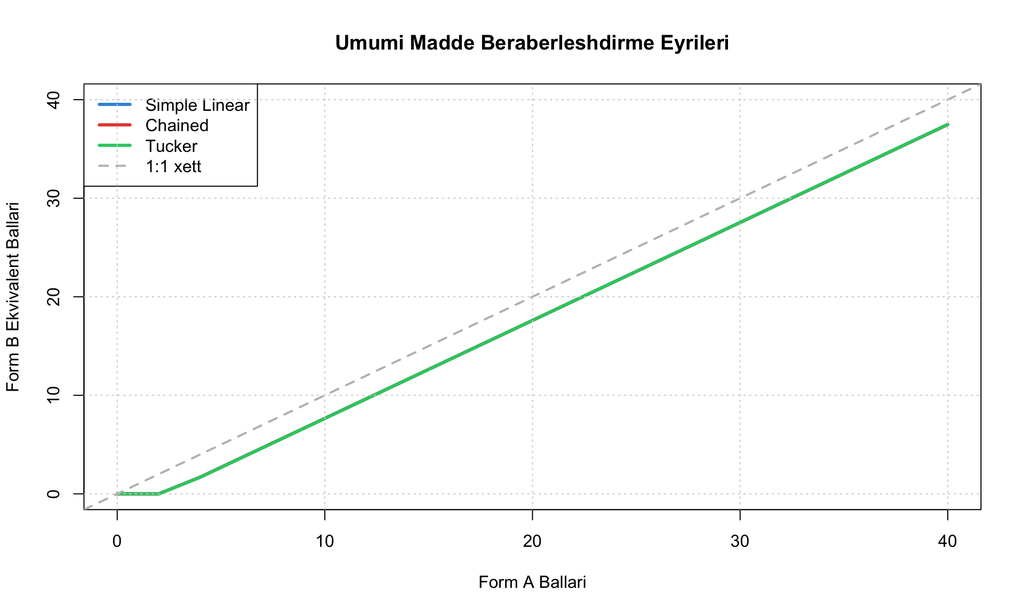

```r
# Transformasiya eyrielerinin vizualizasiyasi
score_range_ci <- seq(0, 40, 2)

simple_curve_ci <- simple_linear_eq$intercept + simple_linear_eq$slope * score_range_ci
chained_curve_ci <- chained_intercept + chained_slope * score_range_ci
tucker_curve_ci <- tucker_eq$intercept + tucker_eq$slope * score_range_ci

# Mehdudlasdirma
simple_curve_ci <- pmax(0, pmin(40, simple_curve_ci))
chained_curve_ci <- pmax(0, pmin(40, chained_curve_ci))
tucker_curve_ci <- pmax(0, pmin(40, tucker_curve_ci))

plot(score_range_ci, simple_curve_ci, type = "l", col = colors_custom[1], lwd = 3,
     main = "Umumi Madde Beraberleshdirme Eyrileri",
     xlab = "Form A Ballari", ylab = "Form B Ekvivalent Ballari",
     xlim = c(0, 40), ylim = c(0, 40))

lines(score_range_ci, chained_curve_ci, col = colors_custom[2], lwd = 3)
lines(score_range_ci, tucker_curve_ci, col = colors_custom[3], lwd = 3)
abline(0, 1, col = "gray", lty = 2, lwd = 2)

legend("topleft",
       c("Simple Linear", "Chained", "Tucker", "1:1 xett"),
       col = c(colors_custom[1:3], "gray"),
       lty = c(1, 1, 1, 2), lwd = c(3, 3, 3, 2))
grid()
```

# 4 Ümumi Şəxs Dizaynı

## 4.1 Ümumi Şəxs Dizaynının Əsasları

Ümumi şəxs dizaynında eyni iştirakçılar hər iki test formasını verir. Bu dizayn ən güclü əlaqələndirməni təmin edir, lakin praktiki çətinlikləri var.

### 4.1.1 Dizayn Xüsusiyyətləri

Umumi Sexs Dizayninin Esas Xususiyyetleri

[output not shown]